# Real-world R for Actuaries

Data Manipulation to Build Claims Triangles

Author

Mick Cooney mcooney@describedata.com

Published

July 3, 2024

# 1 Load Claim Transactions Data

First we load up the transactional data for the claims

```r
claim_cols <- cols(
  country_code = col_character(),
  year         = col_integer()
  )

read_claim_file <- function(file_path) {
  data_tbl <- read_csv(
    file = file_path,
    col_types = claim_cols
    )

  return(data_tbl)
}

claim_transactions_tbl <- dir_info(
    "data",
    regexp = "claims_data\\.csv"
    ) |>
  filter(size > 0) |>
  select(path) |>
  mutate(
    file_data = map(path, read_claim_file)
    ) |>
  unnest(file_data) |>
  select(-path)

claim_transactions_tbl |> glimpse()
```

```
Rows: 452,268
Columns: 8
$ country_code     <chr> "AUT", "AUT", "AUT", "AUT", "AUT", "AUT", "AUT", "AUT…
$ year             <int> 2000, 2000, 2000, 2000, 2000, 2000, 2000, 2000, 2000,…
$ claim_id         <chr> "AUT200001CL0001", "AUT200001CL0001", "AUT200001CL000…
$ incident_date    <date> 2000-01-03, 2000-01-03, 2000-01-05, 2000-01-05, 2000…
$ report_date      <date> 2000-01-20, 2000-01-20, 2000-01-13, 2000-01-13, 2000…
$ transaction_date <date> 2001-10-06, 2007-08-31, 2000-03-12, 2001-05-30, 2005…
$ claim_type       <chr> "PD", "PD", "PD", "PD", "PD", "PD", "PD", "PD", "PD",…
$ amount           <dbl> 501.87, 1195.22, 80.06, 406.39, 644.63, 386.06, 292.0…
```

```r
claim_transactions_tbl |> print()
```

```
# A tibble: 452,268 × 8
   country_code  year claim_id        incident_date report_date transaction_date
   <chr>        <int> <chr>           <date>        <date>      <date>
 1 AUT           2000 AUT200001CL0001 2000-01-03    2000-01-20  2001-10-06
 2 AUT           2000 AUT200001CL0001 2000-01-03    2000-01-20  2007-08-31
 3 AUT           2000 AUT200001CL0002 2000-01-05    2000-01-13  2000-03-12
 4 AUT           2000 AUT200001CL0002 2000-01-05    2000-01-13  2001-05-30
 5 AUT           2000 AUT200001CL0002 2000-01-05    2000-01-13  2005-04-18
 6 AUT           2000 AUT200001CL0003 2000-01-06    2000-01-15  2001-02-27
 7 AUT           2000 AUT200001CL0003 2000-01-06    2000-01-15  2001-08-01
 8 AUT           2000 AUT200001CL0003 2000-01-06    2000-01-15  2001-10-09
 9 AUT           2000 AUT200001CL0003 2000-01-06    2000-01-15  2002-01-24
10 AUT           2000 AUT200001CL0003 2000-01-06    2000-01-15  2002-05-09
# ℹ 452,258 more rows
# ℹ 2 more variables: claim_type <chr>, amount <dbl>
```

## 1.1 Build Quick Year Triangles

Now we want to build a quick claim triangle

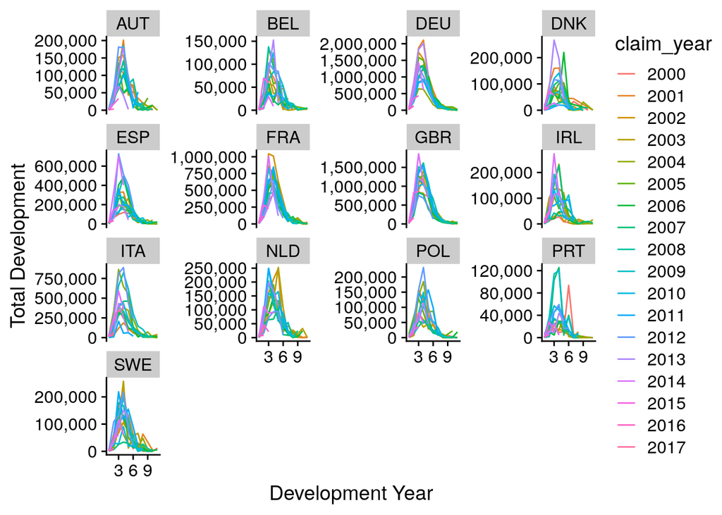

```r
bad_triangle_tbl <- claim_transactions_tbl |>
  mutate(
    claim_year = year,
    value_year = transaction_date |>
      format('%Y') |>
      as.numeric()
    ) |>
  select(
    country_code, claim_id, claim_type, claim_year, value_year, amount
    ) |>
  group_by(country_code, claim_type, claim_year, value_year) |>
  summarise(
    .groups = "drop",

    total_amount = sum(amount)
    ) |>
  mutate(
    dev_year = value_year - claim_year + 1
    ) |>
  ungroup() |>
  select(country_code, claim_type, claim_year, dev_year, total_amount)


bi_plot_tbl <- bad_triangle_tbl |> filter(claim_type == 'BI')
pd_plot_tbl <- bad_triangle_tbl |> filter(claim_type == 'PD')

ggplot(bi_plot_tbl |> mutate(claim_year = claim_year |> as.character())) +
  geom_line(aes(x = dev_year, y = total_amount, colour = claim_year)) +
  facet_wrap(vars(country_code), scales = 'free_y') +
  scale_y_continuous(labels = label_comma()) +
  xlab('Development Year') +
  ylab('Total Development')
```

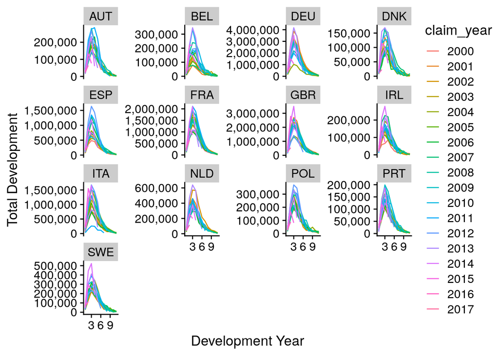

```r
ggplot(pd_plot_tbl |> mutate(claim_year = claim_year |> as.character())) +
  geom_line(aes(x = dev_year, y = total_amount, colour = claim_year)) +
  facet_wrap(vars(country_code), scales = 'free_y') +
  scale_y_continuous(labels = label_comma()) +
  xlab('Development Year') +
  ylab('Total Development')
```

## 1.2 Fixing Triangle Calculation

We are not properly rolling forward claims after they are done developing, so we need to back fill all those.

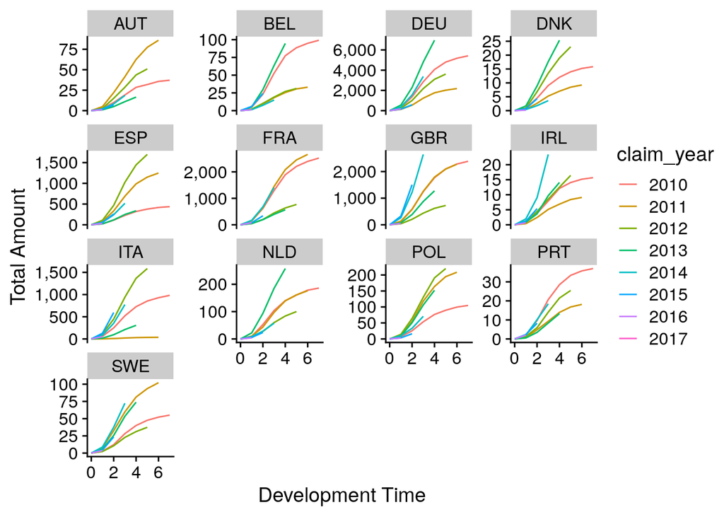

```r
movements_tbl <- claim_transactions_tbl |>
  mutate(
    claim_year = year,
    trans_year = transaction_date |> format('%Y') |> as.numeric(),
    dev_time   = trans_year - claim_year + 1
    ) |>
  group_by(claim_id, dev_time) |>
  top_n(1, wt = transaction_date) |>
  ungroup() |>
  select(country_code, claim_type, claim_year, claim_id, dev_time, amount)



triangle_zero_tbl <- movements_tbl |>
  select(country_code, claim_type, claim_year, claim_id) |>
  distinct() |>
  mutate(
    dev_time = 0,
    amount   = 0
    )


calc_incr_tbl <- list(triangle_zero_tbl, movements_tbl) |>
  bind_rows() |>
  group_by(country_code, claim_type, claim_year, claim_id) |>
  arrange(dev_time) |>
  mutate(increment = amount - lag(amount)) |>
  ungroup() |>
  arrange(country_code, claim_type, claim_year, claim_id, dev_time) |>
  replace_na(
    list(
      increment = 0
      )
    )

calc_incr_tbl <- calc_incr_tbl |>
  select(claim_id, claim_type, claim_year, dev_time, increment)


incr_values_tbl <- claim_transactions_tbl |>
  select(country_code, claim_type, claim_year = year, claim_id) |>
  distinct() |>
  mutate(data = list(tibble(dev_time = 0:20))) |>
  unnest(data) |>
  left_join(calc_incr_tbl, by = c('claim_id', 'claim_type', 'claim_year', 'dev_time')) |>
  replace_na(
    list(
      increment = 0
      )
    )


full_dev_tbl <- incr_values_tbl |>
  group_by(country_code, claim_type, claim_year) |>
  arrange(dev_time) |>
  mutate(
    cuml_amount = cumsum(increment)
    ) |>
  ungroup() |>
  arrange(country_code, claim_type, claim_year, claim_id, dev_time)

long_triangle_tbl <- full_dev_tbl |>
  group_by(country_code, claim_type, claim_year, dev_time) |>
  summarise(total_cuml = sum(cuml_amount)) |>
  ungroup() |>
  filter(
    claim_year + dev_time <= 2017
    )


long_bi_tbl <- long_triangle_tbl |>
  filter(
    claim_type == 'BI',
    claim_year >= 2010
    ) |>
  mutate(
    claim_year = claim_year |> as.character(),
    total_cuml = total_cuml / 1e6
    )

long_pd_tbl <- long_triangle_tbl |>
  filter(
    claim_type == 'PD',
    claim_year >= 2010
    ) |>
  mutate(
    claim_year = claim_year |> as.character(),
    total_cuml = total_cuml / 1e6
    )


ggplot(long_pd_tbl) +
  geom_line(aes(x = dev_time, y = total_cuml, colour = claim_year)) +
  facet_wrap(vars(country_code), scales = 'free_y') +
  scale_y_continuous(labels = label_comma()) +
  xlab("Development Time") +
  ylab("Total Amount")
```

## 1.3 Write to Disk

```r
long_triangle_tbl |> write_rds('data/yearly_triangles.rds')
```

# 2 Build Triangles with Incremental Data

The most straightforward method to build the triangles is likely via incremental values for the claim movements.

The data we have shows the current value for the claim - we need to switch this data to incrementals first, and then work from that.

Once we have the incremental values, we then calculate the development time.

Rather than our previous approach to calculating the development period for the increment we instead use the number of days since the incident and divide by 365.25. As we are assuming no development at time 0, we add 1 to each development year.

```r
claim_incrementals_tbl <- claim_transactions_tbl |>
  group_by(country_code, year, claim_id, claim_type) |>
  mutate(incremental = diff(c(0, amount))) |>
  ungroup() |>
  mutate(
    dev_days = as.numeric(transaction_date - incident_date),
    dev_year = floor(dev_days / 365.25) + 1
    )

claim_incrementals_tbl |> glimpse()
```

```
Rows: 452,268
Columns: 11
$ country_code     <chr> "AUT", "AUT", "AUT", "AUT", "AUT", "AUT", "AUT", "AUT…
$ year             <int> 2000, 2000, 2000, 2000, 2000, 2000, 2000, 2000, 2000,…
$ claim_id         <chr> "AUT200001CL0001", "AUT200001CL0001", "AUT200001CL000…
$ incident_date    <date> 2000-01-03, 2000-01-03, 2000-01-05, 2000-01-05, 2000…
$ report_date      <date> 2000-01-20, 2000-01-20, 2000-01-13, 2000-01-13, 2000…
$ transaction_date <date> 2001-10-06, 2007-08-31, 2000-03-12, 2001-05-30, 2005…
$ claim_type       <chr> "PD", "PD", "PD", "PD", "PD", "PD", "PD", "PD", "PD",…
$ amount           <dbl> 501.87, 1195.22, 80.06, 406.39, 644.63, 386.06, 292.0…
$ incremental      <dbl> 501.87, 693.35, 80.06, 326.33, 238.24, 386.06, -94.06…
$ dev_days         <dbl> 642, 2797, 67, 511, 1930, 418, 573, 642, 749, 854, 10…
$ dev_year         <dbl> 2, 8, 1, 2, 6, 2, 2, 2, 3, 3, 3, 5, 3, 4, 5, 6, 1, 2,…
```

```r
claim_incrementals_tbl |> print()
```

```
# A tibble: 452,268 × 11
   country_code  year claim_id        incident_date report_date transaction_date
   <chr>        <int> <chr>           <date>        <date>      <date>
 1 AUT           2000 AUT200001CL0001 2000-01-03    2000-01-20  2001-10-06
 2 AUT           2000 AUT200001CL0001 2000-01-03    2000-01-20  2007-08-31
 3 AUT           2000 AUT200001CL0002 2000-01-05    2000-01-13  2000-03-12
 4 AUT           2000 AUT200001CL0002 2000-01-05    2000-01-13  2001-05-30
 5 AUT           2000 AUT200001CL0002 2000-01-05    2000-01-13  2005-04-18
 6 AUT           2000 AUT200001CL0003 2000-01-06    2000-01-15  2001-02-27
 7 AUT           2000 AUT200001CL0003 2000-01-06    2000-01-15  2001-08-01
 8 AUT           2000 AUT200001CL0003 2000-01-06    2000-01-15  2001-10-09
 9 AUT           2000 AUT200001CL0003 2000-01-06    2000-01-15  2002-01-24
10 AUT           2000 AUT200001CL0003 2000-01-06    2000-01-15  2002-05-09
# ℹ 452,258 more rows
# ℹ 5 more variables: claim_type <chr>, amount <dbl>, incremental <dbl>,
#   dev_days <dbl>, dev_year <dbl>
```

We want to ensure that every claim gets an entry for each development period.

To do this we fill out the each development period for each year, and then join this data on.

```r
acc_year <- claim_incrementals_tbl |> pull(year)     |> unique()
dev_year <- claim_incrementals_tbl |> pull(dev_year) |> unique()

all_tbl <- claim_incrementals_tbl |>
  select(country_code, claim_type, year) |>
  distinct()

full_incr_tbl <- crossing(
    year     = acc_year,
    dev_year = c(0, dev_year)
    ) |>
  left_join(
    all_tbl, by = 'year',
    relationship = "many-to-many"
    )
```

```r
data_dev_tbl <- claim_incrementals_tbl |>
  group_by(country_code, year, claim_type, dev_year) |>
  summarise(
    .groups = "drop",

    total_incr = sum(incremental)
    )


data_dev_tbl |> glimpse()
```

```
Rows: 3,362
Columns: 5
$ country_code <chr> "AUT", "AUT", "AUT", "AUT", "AUT", "AUT", "AUT", "AUT", "…
$ year         <int> 2000, 2000, 2000, 2000, 2000, 2000, 2000, 2000, 2000, 200…
$ claim_type   <chr> "BI", "BI", "BI", "BI", "BI", "BI", "BI", "BI", "BI", "BI…
$ dev_year     <dbl> 1, 2, 3, 4, 5, 6, 7, 8, 9, 10, 1, 2, 3, 4, 5, 6, 7, 8, 9,…
$ total_incr   <dbl> 2880.04, 60326.82, 59312.32, 6811.17, 10027.10, 134.31, 6…
```

```r
data_dev_tbl |> print()
```

```
# A tibble: 3,362 × 5
   country_code  year claim_type dev_year total_incr
   <chr>        <int> <chr>         <dbl>      <dbl>
 1 AUT           2000 BI                1      2880.
 2 AUT           2000 BI                2     60327.
 3 AUT           2000 BI                3     59312.
 4 AUT           2000 BI                4      6811.
 5 AUT           2000 BI                5     10027.
 6 AUT           2000 BI                6       134.
 7 AUT           2000 BI                7        69
 8 AUT           2000 BI                8       641.
 9 AUT           2000 BI                9      1376.
10 AUT           2000 BI               10      4778.
# ℹ 3,352 more rows
```

```r
claim_dev_vals_tbl <- full_incr_tbl |>
  left_join(data_dev_tbl, by = c('country_code', 'year', 'claim_type', 'dev_year')) |>
  replace_na(list(total_incr = 0)) |>
  select(country_code, claim_type, year, dev_year, total_incr) |>
  arrange(country_code, claim_type, year, dev_year)

claim_dev_vals_tbl |> glimpse()
```

```
Rows: 5,093
Columns: 5
$ country_code <chr> "AUT", "AUT", "AUT", "AUT", "AUT", "AUT", "AUT", "AUT", "…
$ claim_type   <chr> "BI", "BI", "BI", "BI", "BI", "BI", "BI", "BI", "BI", "BI…
$ year         <int> 2000, 2000, 2000, 2000, 2000, 2000, 2000, 2000, 2000, 200…
$ dev_year     <dbl> 0, 1, 2, 3, 4, 5, 6, 7, 8, 9, 10, 0, 1, 2, 3, 4, 5, 6, 7,…
$ total_incr   <dbl> 0.00, 2880.04, 60326.82, 59312.32, 6811.17, 10027.10, 134…
```

```r
claim_dev_vals_tbl |> print()
```

```
# A tibble: 5,093 × 5
   country_code claim_type  year dev_year total_incr
   <chr>        <chr>      <int>    <dbl>      <dbl>
 1 AUT          BI          2000        0         0
 2 AUT          BI          2000        1      2880.
 3 AUT          BI          2000        2     60327.
 4 AUT          BI          2000        3     59312.
 5 AUT          BI          2000        4      6811.
 6 AUT          BI          2000        5     10027.
 7 AUT          BI          2000        6       134.
 8 AUT          BI          2000        7        69
 9 AUT          BI          2000        8       641.
10 AUT          BI          2000        9      1376.
# ℹ 5,083 more rows
```

We are now in a position to calculate the cumulative amounts for each year.

```r
claim_dev_long_tbl <- claim_dev_vals_tbl |>
  group_by(country_code, claim_type, year) |>
  arrange(year) |>
  mutate(dev_amount = cumsum(total_incr)) |>
  ungroup() |>
  arrange(country_code, claim_type, year, dev_year)

claim_dev_long_tbl |> glimpse()
```

```
Rows: 5,093
Columns: 6
$ country_code <chr> "AUT", "AUT", "AUT", "AUT", "AUT", "AUT", "AUT", "AUT", "…
$ claim_type   <chr> "BI", "BI", "BI", "BI", "BI", "BI", "BI", "BI", "BI", "BI…
$ year         <int> 2000, 2000, 2000, 2000, 2000, 2000, 2000, 2000, 2000, 200…
$ dev_year     <dbl> 0, 1, 2, 3, 4, 5, 6, 7, 8, 9, 10, 0, 1, 2, 3, 4, 5, 6, 7,…
$ total_incr   <dbl> 0.00, 2880.04, 60326.82, 59312.32, 6811.17, 10027.10, 134…
$ dev_amount   <dbl> 0.00, 2880.04, 63206.86, 122519.18, 129330.35, 139357.45,…
```

```r
claim_dev_long_tbl |> print()
```

```
# A tibble: 5,093 × 6
   country_code claim_type  year dev_year total_incr dev_amount
   <chr>        <chr>      <int>    <dbl>      <dbl>      <dbl>
 1 AUT          BI          2000        0         0          0
 2 AUT          BI          2000        1      2880.      2880.
 3 AUT          BI          2000        2     60327.     63207.
 4 AUT          BI          2000        3     59312.    122519.
 5 AUT          BI          2000        4      6811.    129330.
 6 AUT          BI          2000        5     10027.    139357.
 7 AUT          BI          2000        6       134.    139492.
 8 AUT          BI          2000        7        69     139561.
 9 AUT          BI          2000        8       641.    140202.
10 AUT          BI          2000        9      1376.    141578.
# ℹ 5,083 more rows
```

We spread this table to ‘wide’ format:

```r
claim_dev_wide_tbl <- claim_dev_long_tbl |>
  select(-total_incr) |>
  spread(dev_year, dev_amount)

claim_dev_wide_tbl |> glimpse()
```

```
Rows: 463
Columns: 14
$ country_code <chr> "AUT", "AUT", "AUT", "AUT", "AUT", "AUT", "AUT", "AUT", "…
$ claim_type   <chr> "BI", "BI", "BI", "BI", "BI", "BI", "BI", "BI", "BI", "BI…
$ year         <int> 2000, 2001, 2002, 2003, 2004, 2005, 2006, 2007, 2008, 200…
$ `0`          <dbl> 0, 0, 0, 0, 0, 0, 0, 0, 0, 0, 0, 0, 0, 0, 0, 0, 0, 0, 0, …
$ `1`          <dbl> 2880.04, 34201.85, 1972.39, 9353.41, 17217.62, 7813.71, 4…
$ `2`          <dbl> 63206.86, 53631.39, 118727.13, 53948.12, 52503.87, 48502.…
$ `3`          <dbl> 122519.18, 132224.10, 128342.47, 77550.21, 86360.97, 8364…
$ `4`          <dbl> 129330.35, 164794.71, 131496.39, 119592.78, 100740.21, 11…
$ `5`          <dbl> 139357.45, 185709.37, 149759.02, 138790.28, 150032.47, 11…
$ `6`          <dbl> 139491.76, 186382.06, 149232.24, 133026.83, 156007.40, 11…
$ `7`          <dbl> 139560.76, 185430.34, 151320.01, 132902.17, 156286.09, 11…
$ `8`          <dbl> 140201.83, 185373.53, 159142.41, 133219.85, 155114.79, 12…
$ `9`          <dbl> 141578.06, 185373.53, 159142.41, 132103.10, 160147.62, 12…
$ `10`         <dbl> 146355.63, 185373.46, 158577.28, 132059.80, 160147.65, 12…
```

```r
claim_dev_wide_tbl |> print()
```

```
# A tibble: 463 × 14
   country_code claim_type  year   `0`    `1`    `2`    `3`    `4`    `5`    `6`
   <chr>        <chr>      <int> <dbl>  <dbl>  <dbl>  <dbl>  <dbl>  <dbl>  <dbl>
 1 AUT          BI          2000     0  2880. 6.32e4 1.23e5 1.29e5 1.39e5 1.39e5
 2 AUT          BI          2001     0 34202. 5.36e4 1.32e5 1.65e5 1.86e5 1.86e5
 3 AUT          BI          2002     0  1972. 1.19e5 1.28e5 1.31e5 1.50e5 1.49e5
 4 AUT          BI          2003     0  9353. 5.39e4 7.76e4 1.20e5 1.39e5 1.33e5
 5 AUT          BI          2004     0 17218. 5.25e4 8.64e4 1.01e5 1.50e5 1.56e5
 6 AUT          BI          2005     0  7814. 4.85e4 8.36e4 1.12e5 1.15e5 1.16e5
 7 AUT          BI          2006     0  4704. 4.46e4 6.42e4 9.01e4 9.23e4 9.38e4
 8 AUT          BI          2007     0  4961. 3.93e4 7.69e4 8.27e4 9.10e4 9.38e4
 9 AUT          BI          2008     0  7085. 3.81e4 8.96e4 1.37e5 1.52e5 1.59e5
10 AUT          BI          2009     0  4892. 5.25e4 6.88e4 1.06e5 1.23e5 1.25e5
# ℹ 453 more rows
# ℹ 4 more variables: `7` <dbl>, `8` <dbl>, `9` <dbl>, `10` <dbl>
```

# 3 Split Claims Data

```r
countries <- claim_transactions_tbl |> count(country_code) |> pull(country_code)

for(country in countries) {
  output_file <- glue("data/{country}_claims_data.csv")

  claim_transactions_tbl |>
    filter(country_code == country) |>
    write_csv(file = output_file)
}

transactions_file <- "data/claims_transactions_tbl.rds"

claim_transactions_tbl |>
  write_rds(file = transactions_file)
```